# Data Visualization HW1: Full time clinicians by state in Nigeria

Jamie Hirsch

Wednesday, February 4, 2015

#### The following data shows the number of fulltime clinicians (doctors and nurses) by state in Nigeria, based upon the Nigeria MDG Information System.

> For this code, you will need the following R packages: `dplyr`, `tidyr`, and `tabplot`.

The data needs to be read into R:

```r
lgas <- read.csv("lgas.csv")
nmis <- read.csv("Health_Mopup_and_Baseline_NMIS_Facility.csv")
```

Merging of `nmis` and `lgas` will be performed by `unique_lga` column, which is in both dataframes. There are differences in spelling (or misspellings) between the variables in that column between the 2 dataframes. Here are the names in each dataframe that are missing an exact match:

```r
unique_lga_diff <- data.frame(
    c(sort(setdiff(nmis$unique_lga, lgas$unique_lga)), NA),
    sort(setdiff(lgas$unique_lga, nmis$unique_lga)))
colnames(unique_lga_diff) <- c("NMIS", "LGAS")
```

```
##                        NMIS                  LGAS
## 1             abia_obi_ngwa          abia_obi_nwa
## 2           abia_umunneochi       abia_umu_neochi
## 3           adamawa_lamurde      adamawa_larmurde
## 4          adamawa_madagali       adamawa_madgali
## 5      akwa_ibom_nsit_ubium  akwa_ibom_nsit_ubuim
## 6             bauchi_dambam         bauchi_damban
## 7  bayelsa_kolokuma_opokuma      bayelsa_kolokuma
## 8       cross_river_bakassi          borno_abadam
## 9               edo_igueben           borno_gwoza
## 10           edo_orhionmwon          edo_iguegben
## 11         enugu_nkanu_east         edo_ohionmwon
## 12       gombe_yamaltu_deba           enugu_nkanu
## 13               imo_onuimo    gombe_yalmatu_deba
## 14      jigawa_malam_madori            imo_unuimo
## 15    jigawa_sule_tankarkar   jigawa_malam_maduri
## 16           kogi_olamaboro  jigawa_sule_tankakar
## 17              niger_munya        kogi_olamabolo
## 18          ogun_yewa_north            niger_moya
## 19          ogun_yewa_south     ogun_egbado_north
## 20   plateau_langtang_north     ogun_egbado_south
## 21          rivers_ogu_bolo plateau_langtan_north
## 22            rivers_omumma       rivers_ogo_bolo
## 23            sokoto_wamako          rivers_omuma
## 24      taraba_karim_lamido        sokoto_wammako
## 25                     <NA>   taraba_karin_lamido
```

We can do partial matching (using `agrep`) of items that don’t appear to match between dataframes. This results in a list (named `match`). A vector is then created from this list (named `match_vec`) and added (using `cbind`) to the dataframe.

Note that the numbers correspond to `match` in the NMIS row for the given LGAS column, e.g., `abia_obi_ngwa abia_obi_nwa 1`, means that column 2 (which is LGAS) for this row matches to row 1 in the NMIS column.

```r
match <- sapply(unique_lga_diff[1:25, 2],
                function(x) agrep(x, unique_lga_diff$NMIS))

match_vec <- c(1, 2, 3, 4, 5, 6, 7, 0, 0, 9, 10, 11, 12, 13, 14,
               15, 16, 0, 0, 0, 20, 21, 22, 23, 24)

unique_lga_diff <- cbind(unique_lga_diff, match_vec)
```

Following a review, some manual adjustments and updates were made to the matching.

[output not shown]

Finally, we loop through the `unique_lga` column in the `lgas` dataframe and replace spellings to match the `nmis` dataframe. (Unfortunately, here I used clunky nested loops!)

```r
for(i in 1:length(lgas$unique_lga)){
    for(j in 1:length(unique_lga_diff$LGAS)){
        if(lgas$unique_lga[i] == unique_lga_diff$LGAS[j]){
            match_id <- unique_lga_diff[j, "match_vec"]
            if(match_id > 0){
                new_id <- unique_lga_diff[match_id, "NMIS"]
                lgas$unique_lga[i] = new_id
            }
        }
    }
}
```

Now that everything is cleaned up, we want to find clinicians in the Southern zones of Nigeria. First we need to identify the names of the Southern zones:

```r
table(lgas$zone)
```

```
##
## North-Central     Northeast     Northwest   South-South     Southeast     Southwest
##           121           112           187           122            95           137
```

Subset the LGAs data in order to identify only those in the Southern zone (this dataframe will be needed later when we do more extensive statistics):

```r
lgas_south <- lgas %>% filter(
    zone  == "South-South"
    | zone == "Southeast"
    | zone == "Southwest")
```

Merging of `nmis` and `lgas` will be performed by the `unique_lga` column, which is in both dataframes. The spelling differences have already been settled.

The Southern facilities can be identified by merging the ’lgas`dataframe into the`nmis` dataframe and subsetting by Southern zone:

```r
data_south <- nmis %>%
    left_join(lgas, by = "unique_lga") %>%
    filter(
        zone == "South-South"
        | zone == "Southeast"
        | zone == "Southwest")
```

This results in a large dataframe. Here is the structure:

```r
str(data_south)
```

```
## 'data.frame':    14562 obs. of  42 variables:
##  $ facility_name                    : Factor w/ 28550 levels "                                                                                                                               "| __truncated__,..: 10496 23086 20322 10286 26394 10563 27789 14315 26581 13967 ...
##  $ facility_type_display            : Factor w/ 18 levels "Basic Health Centre / Primary Health Clinic",..: 9 1 14 9 9 9 16 16 16 16 ...
##  $ maternal_health_delivery_services: logi  TRUE TRUE TRUE TRUE TRUE FALSE ...
##  $ emergency_transport              : logi  TRUE TRUE FALSE FALSE TRUE FALSE ...
##  $ skilled_birth_attendant          : logi  FALSE TRUE FALSE FALSE TRUE FALSE ...
##  $ num_chews_fulltime               : int  1 2 2 0 0 0 1 4 1 0 ...
##  $ phcn_electricity                 : logi  TRUE TRUE FALSE FALSE FALSE FALSE ...
##  $ c_section_yn                     : logi  FALSE TRUE FALSE FALSE TRUE FALSE ...
##  $ child_health_measles_immun_calc  : logi  TRUE TRUE TRUE TRUE FALSE TRUE ...
##  $ num_nurses_fulltime              : int  0 4 0 0 2 1 6 NA 3 6 ...
##  $ num_nursemidwives_fulltime       : int  0 11 0 0 0 0 12 4 1 2 ...
##  $ num_doctors_fulltime             : int  0 2 0 0 1 0 5 15 0 2 ...
##  $ date_of_survey                   : Factor w/ 323 levels "2009-07-23","2010-10-20",..: 240 249 242 242 244 240 241 241 259 259 ...
##  $ facility_id                      : Factor w/ 34122 levels "AAABW","AAADE",..: 28724 10978 16657 17973 17419 13808 10914 12589 8626 18236 ...
```

[output cut: 28 more lines]

To then set up the process for finding total clinicians by state, we first categorize population and area by state in a dataframe:

```r
population_area <- lgas_south %>%
    group_by(state) %>%
    summarise(population = sum(pop_2006, na.rm = TRUE),
              area_sq_km = sum(area_sq_km, na.rm = TRUE))
```

```
## Source: local data frame [17 x 3]
##
##          state population area_sq_km
## 1         Abia    2833999   4857.434
## 2    Akwa Ibom    3920208   6720.579
## 3      Anambra    4182032   4762.182
## 4      Bayelsa    1703358   9368.015
## 5  Cross River    2856581  20936.867
## 6        Delta    4098391  17105.597
## 7       Ebonyi    2173501   6342.013
## 8          Edo    3218332  19596.676
## 9        Ekiti    2384212   5801.502
## 10       Enugu    3257298   7561.111
## 11         Imo    3934899   5136.055
## 12       Lagos    9013534   3479.717
## 13        Ogun    3728098  16873.168
## 14        Ondo    3441024  15031.599
## 15        Osun    3423535   8595.119
## 16         Oyo    5591589  27900.302
## 17      Rivers    5185400  10363.981
```

Next, we find the number of doctors, nurses, and their sum by state, merge this dataframe with the previous one, and then find the total number of clinicians per capita and per area, and arrange the dataframe in descending order by the population column:

```r
fulltime <- data_south %>%
    group_by(state) %>%
    summarise(doctors = sum(num_doctors_fulltime, na.rm = TRUE),
              nurses = sum(num_nurses_fulltime, na.rm = TRUE)) %>%
    mutate(total_clinician = doctors + nurses) %>%
    left_join(population_area, by = "state") %>%
    mutate(per_capita_clinician = total_clinician / population,
           per_area_clinician = total_clinician / area_sq_km) %>%
    arrange(desc(population))
```

```
##          state doctors nurses total_clinician population area_sq_km per_capita_clinician per_area_clinician
## 1        Lagos    2884   3154            6038    9013534   3479.717         0.0006698815         1.73519865
## 2          Oyo    1021   1593            2614    5591589  27900.302         0.0004674879         0.09369074
## 3       Rivers     698   1108            1806    5185400  10363.981         0.0003482856         0.17425735
## 4      Anambra     723   1723            2446    4182032   4762.182         0.0005848831         0.51363012
## 5        Delta     669   1183            1852    4098391  17105.597         0.0004518847         0.10826866
## 6          Imo     962   2138            3100    3934899   5136.055         0.0007878220         0.60357604
## 7    Akwa Ibom     269    653             922    3920208   6720.579         0.0002351916         0.13719056
## 8         Ogun    1157   2238            3395    3728098  16873.168         0.0009106520         0.20120703
## 9         Ondo     455    592            1047    3441024  15031.599         0.0003042699         0.06965327
## 10        Osun     487    989            1476    3423535   8595.119         0.0004311333         0.17172536
## 11       Enugu     587   1139            1726    3257298   7561.111         0.0005298870         0.22827334
## 12         Edo     919   1045            1964    3218332  19596.676         0.0006102540         0.10022108
## 13 Cross River     321    903            1224    2856581  20936.867         0.0004284843         0.05846147
## 14        Abia     910    849            1759    2833999   4857.434         0.0006206777         0.36212532
## 15       Ekiti     529    611            1140    2384212   5801.502         0.0004781454         0.19650084
## 16      Ebonyi     234    472             706    2173501   6342.013         0.0003248216         0.11132112
## 17     Bayelsa     144    237             381    1703358   9368.015         0.0002236758         0.04067030
```

Just for fun, to quickly visualize this entire dataframe (in descending order of population, matching the table):

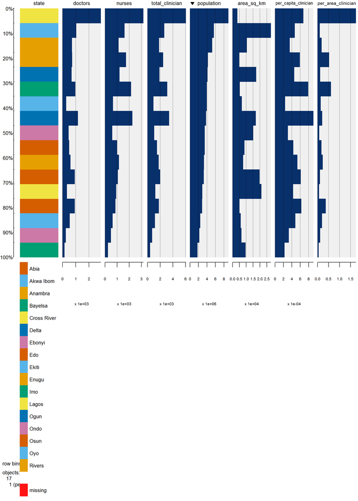